# Exploratory Data Analysis on Fuel Efficiency: Correlation Analysis and Visualization. Created by MBUBA Priscillia

```python
import numpy as np
import pandas as pd
import seaborn as sns
import matplotlib.pyplot as plt
```

# “FuelEfficiency.csv” dataset

```python
# Importing data named "FuelEfficiency.csv"
FuelEfficiency = pd.read_csv('FuelEfficiency.csv')
```

```python
# displaying the data
FuelEfficiency
```

|  | Model | Eng Size | Cylinders | MSRP | City_L/100km | Highway_L/100km | Weight_in_Pounds | Type | Country |
| --- | --- | --- | --- | --- | --- | --- | --- | --- | --- |
| 0 | A4 | 1.8 | 4 | 25550 | 12.8 | 9.1 | 3252 | Sedan | Germany |
| 1 | 3_Series | 2.5 | 6 | 28100 | 14.1 | 9.7 | 3219 | Sedan | Germany |
| 2 | G35 | 3.5 | 6 | 28150 | 15.7 | 10.9 | 3336 | Sedan | Japan |
| 3 | X-Type | 2.5 | 6 | 29330 | 14.9 | 10.1 | 3428 | Sedan | England |
| 4 | C-class | 1.8 | 4 | 29250 | 12.8 | 9.4 | 3250 | Sedan | Germany |
| ... | ... | ... | ... | ... | ... | ... | ... | ... | ... |
| 79 | Element_EX | 2.4 | 4 | 19700 | 12.8 | 10.9 | 3441 | SUV | Japan |
| 80 | Escape_XLS | 3.0 | 6 | 20400 | 14.9 | 11.3 | 3181 | SUV | US |
| 81 | Liberty_Sport | 2.4 | 4 | 18380 | 14.9 | 11.8 | 3648 | SUV | US |
| 82 | Xterra_XE | 3.3 | 6 | 20500 | 18.8 | 14.9 | 3777 | SUV | Japan |
| 83 | VUE | 2.2 | 4 | 19005 | 12.8 | 10.1 | 3260 | SUV | US |

84 rows × 9 columns

# Checking for missing values in the dataset

```python
# Checking for missing values in the dataset
missing_values = FuelEfficiency.isnull().sum()
print("Missing values in the dataset:\n", missing_values)

# Checking for constant columns
constant_columns = FuelEfficiency.columns[FuelEfficiency.nunique() == 1]
print("Constant columns in the dataset:", constant_columns)
```

```
Missing values in the dataset:
 Model               0
Eng Size            0
Cylinders           0
MSRP                0
City_L/100km        0
Highway_L/100km     0
Weight_in_Pounds    0
Type                0
Country             0
dtype: int64
Constant columns in the dataset: Index([], dtype='object')
```

# The most strongly correlated and weakly correlated pair of the variables in the dataset

```
C:\Users\HP USER\AppData\Local\Temp\ipykernel_10028\1528141619.py:2: FutureWarning: The default value of numeric_only in DataFrame.corr is deprecated. In a future version, it will default to False. Select only valid columns or specify the value of numeric_only to silence this warning.
  correlation_matrix = FuelEfficiency.corr()
```

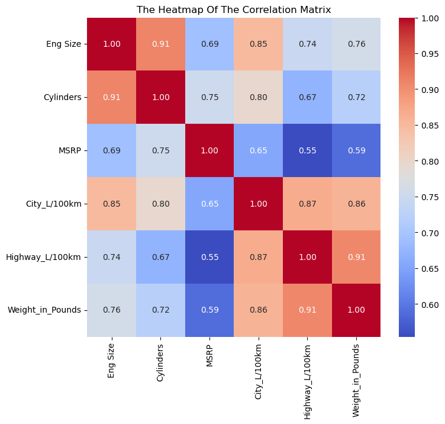

```
Most strongly correlated variables is: ('Eng Size', 'Cylinders') with the Correlation of: 0.9105808011573772
Most weakly correlated variables is: ('MSRP', 'Highway_L/100km') with the Correlation of: 0.5543263090309357
```

```python
# Calculating the correlation matrix
correlation_matrix = FuelEfficiency.corr()

# using heatmap to show the correlation matrix
plt.figure(figsize=(8, 7))
sns.heatmap(correlation_matrix, annot=True, cmap='coolwarm', fmt=".2f")
plt.title("The Heatmap Of The Correlation Matrix")
plt.show()

# Finding the most strongly and most weakly correlated pairs
strongest_pair = None
weakest_pair = None
max_correlation = 0
min_correlation = 1

for i in range(len(correlation_matrix.columns)):
    for j in range(i+1, len(correlation_matrix.columns)):
        # Skipping the diagonal elements and identical pairs
        if i != j:
            correlation = abs(correlation_matrix.iloc[i, j])
            if correlation > max_correlation:
                max_correlation = correlation
                strongest_pair = (correlation_matrix.columns[i], correlation_matrix.columns[j])
            if 0 < correlation < min_correlation:
                min_correlation = correlation
                weakest_pair = (correlation_matrix.columns[i], correlation_matrix.columns[j])

# Printing the results
print("Most strongly correlated variables is:", strongest_pair, "with the Correlation of:", max_correlation)
print("Most weakly correlated variables is:", weakest_pair, "with the Correlation of:", min_correlation)
```

# The minimum and maximum weights (in pounds) in the dataset?

```python
# Finding the minimum and maximum weights
min_weight = FuelEfficiency['Weight_in_Pounds'].min()
max_weight = FuelEfficiency['Weight_in_Pounds'].max()

print("The Minimum weight is:", min_weight, "pounds")
print("The Maximum weight is:", max_weight, "pounds")
```

```
The Minimum weight is: 2469 pounds
The Maximum weight is: 6400 pounds
```

# Determine the descriptive statistics for all of the quantitative columns

```python
# Descriptive statistics for all quantitative columns
quantitative_stats = FuelEfficiency.describe()

print("\nDescriptive Statistics For All Quantitative Columns:")
print(quantitative_stats)
```

```
Descriptive Statistics For All Quantitative Columns:
        Eng Size  Cylinders          MSRP  City_L/100km  Highway_L/100km  \
count  84.000000  84.000000     84.000000     84.000000        84.000000
mean    3.314286   5.845238  31934.690476     15.314286        11.526190
std     1.232115   1.548369  15970.282475      3.633053         3.303234
min     1.500000   4.000000  14400.000000      4.700000         5.500000
25%     2.400000   4.000000  20653.750000     12.800000         9.625000
50%     3.200000   6.000000  26727.500000     14.900000        10.900000
75%     4.200000   6.000000  37558.750000     17.700000        13.500000
max     8.300000  10.000000  81090.000000     25.700000        25.700000

       Weight_in_Pounds
count         84.000000
mean        3809.285714
std          869.868036
min         2469.000000
25%         3242.250000
50%         3571.000000
75%         4323.000000
max         6400.000000
```

# Adding a new column to the dataset named “under_4000”, 1 for cars < 4000 pounds and 0 for cars >/= 4000 pounds.

```python
# Adding a new column "under_4000" based on the weight condition
FuelEfficiency['under_4000'] = (FuelEfficiency['Weight_in_Pounds'] < 4000).astype(int)

# Displaying the last 10 rows of the updated dataset
print(FuelEfficiency.tail(10))
```

```
                 Model  Eng Size  Cylinders   MSRP  City_L/100km  \
74              H2_Lux       6.0          8  52920          25.7
75            Escalade       6.0          8  55110          21.7
76     Range_Rover_HSE       4.4          8  72285          23.5
77  Navigator_Ultimate       5.4          8  56140          16.6
78                G500       5.0          8  76900          23.5
79          Element_EX       2.4          4  19700          12.8
80          Escape_XLS       3.0          6  20400          14.9
81       Liberty_Sport       2.4          4  18380          14.9
82           Xterra_XE       3.3          6  20500          18.8
83                 VUE       2.2          4  19005          12.8

    Highway_L/100km  Weight_in_Pounds  Type  Country  under_4000
74             25.7              6400   SUV       US           0
75             16.6              5571   SUV       US           0
76             17.7              5379   SUV  England           0
77             23.5              6041   SUV       US           0
78             20.2              5423   SUV  Germany           0
79             10.9              3441   SUV    Japan           1
80             11.3              3181   SUV       US           1
81             11.8              3648   SUV       US           1
82             14.9              3777   SUV    Japan           1
83             10.1              3260   SUV       US           1
```

# Determining the correlation between weight in pounds and litres of fuel consumed per 100 km on the highway for cars < 4000 pounds

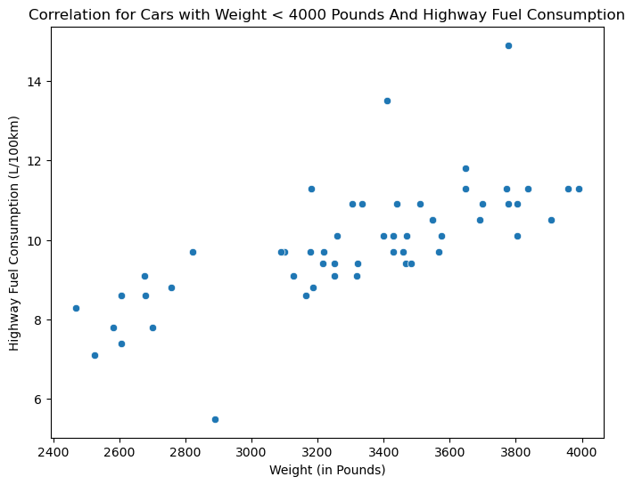

```
Correlation for all cars is: 0.9061661534034026
Correlation for cars with weight < 4000 pounds is: 0.7242554807815628
```

```python
# Calculating correlation for all cars
correlation_all_cars = FuelEfficiency['Weight_in_Pounds'].corr(FuelEfficiency['Highway_L/100km'])

# Filtering cars with weight less than 4000 pounds
filtered_data = FuelEfficiency[FuelEfficiency['Weight_in_Pounds'] < 4000]

# Calculating correlation for cars with weight less than 4000 pounds
correlation_filtered = filtered_data['Weight_in_Pounds'].corr(filtered_data['Highway_L/100km'])


# Visualize the correlation for cars with weight less than 4000 pounds
plt.figure(figsize=(8, 6))
sns.scatterplot(x=filtered_data['Weight_in_Pounds'], y=filtered_data['Highway_L/100km'])
plt.title("Correlation for Cars with Weight < 4000 Pounds And Highway Fuel Consumption")
plt.xlabel("Weight (in Pounds)")
plt.ylabel("Highway Fuel Consumption (L/100km)")
plt.show()

# Print the correlation values
print("Correlation for all cars is:", correlation_all_cars)
print("Correlation for cars with weight < 4000 pounds is:", correlation_filtered)
```

The correlation for all cars (0.9062) indicates a strong positive correlation between weight and highway fuel consumption, suggesting that as the weight of the cars increases, their fuel consumption on the highway tends to also increase.

# The correlation coefficient between highway fuel consumption and weight for vehicles with a weight between 3000 and 4000 pounds. Visualize the correlation

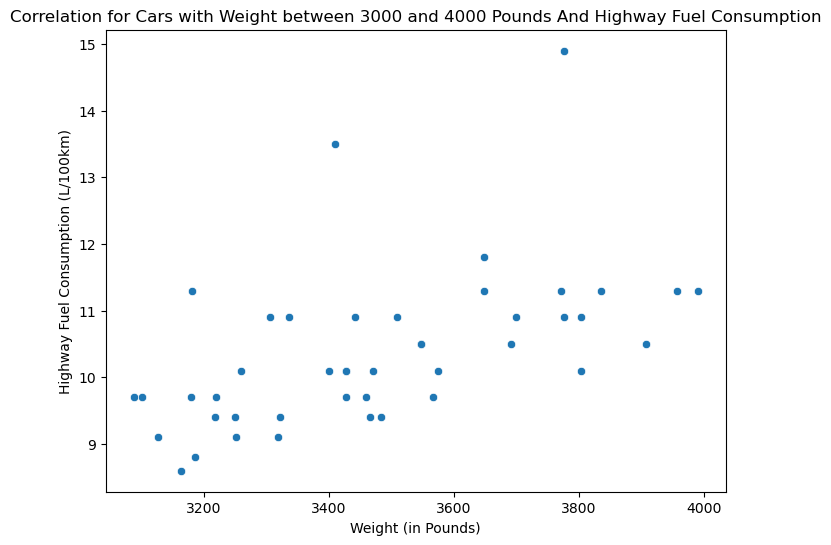

```
Correlation coefficient for cars with weight between 3000 and 4000 pounds is: 0.5331992637793956
```

```python
# Filtering cars with weight between 3000 and 4000 pounds
filtered_data = FuelEfficiency[(FuelEfficiency['Weight_in_Pounds'] >= 3000) & (FuelEfficiency['Weight_in_Pounds'] <= 4000)]

# Calculating correlation between weight and highway fuel consumption
correlation_filtered = filtered_data['Weight_in_Pounds'].corr(filtered_data['Highway_L/100km'])

# Visualizing the correlation
plt.figure(figsize=(8, 6))
sns.scatterplot(x=filtered_data['Weight_in_Pounds'], y=filtered_data['Highway_L/100km'])
plt.title("Correlation for Cars with Weight between 3000 and 4000 Pounds And Highway Fuel Consumption")
plt.xlabel("Weight (in Pounds)")
plt.ylabel("Highway Fuel Consumption (L/100km)")
plt.show()

# Printing the correlation coefficient
print("Correlation coefficient for cars with weight between 3000 and 4000 pounds is:", correlation_filtered)
```